# Intimate Partner Violence among Adolescent Girls and Young Women Living with HIV in Tanzania

Weill Cornell Center for Global Health Biostatistics Internship Project

**Biostatistician:** Ayisha Beauge, Celine Hernandez

**Principal Investigator:** Lindsey Reif

*July 21, 2026*

# Study Background

The purpose of this study is to investigate the relationship of intimate partner violence (IPV) and adolescent girls and young women (AGYW) health with a focus in HIV in Tanzania. IPV has severe consequences for AGYW’s health outcomes which includes increase risk for HIV acquisition, unintended pregnancies, adverse maternal/child health outcome ,and inadequate mental health conditions - including depression and anxiety. The outcomes and findings of this study will help establish epidemiological estimates of these factors in order to create intervention initiatives as well as understand perspectives on gender equity and IPV tolerance in AGYW.

# Study aims

1. Descriptive statistics of the overall cohort
2. Are there differences in clinical markers of CVD (possibility for subgroup) or HIV-related outcomes (viral load) between intimate partner violence (IPV) and non-IPV groups?
3. Does HIV stigma mediate the relationship between IPV and ART adherence?
4. Does depression mediate the relationship between IPV and ART adherence?
5. Does social support buffer (modify) the relationship between IPV and Depression?
6. Amongst the full cohort (not limited to those reporting being in a relationship), what is the relationship between depression and HIV viral suppression?

# Results

```r
library(tidyverse)
library(here)
library(gtsummary)
library(ggplot2)
library(see)
library(scales)
library(mediation)

# make the tables a little smaller
theme_gtsummary_compact()

complete_data <- here("data", "20260708_complete_data.rds") |> readRDS()
```

## 1. Descriptive Statistics

Among the 299 participants included in the full cohort, 62% were adolescents aged 15–19 years and 38% were young adults aged 20–24 years. The median age was 18 years (Q1, Q3: 16, 21). Most participants (64%) had some or all secondary education, and 75% had never been partnered. The majority (86%) had a suppressed HIV viral load, with a median of 10.5 years since HIV diagnosis and 9.8 years since ART initiation. Median systolic and diastolic blood pressures were 102 mmHg (Q1, Q3: 95, 109) and 66 mmHg (Q1, Q3: 60, 72), respectively, with 92% classified as having normal blood pressure. Regarding IPV, 61% reported attitudes accepting of IPV, and among participants with available data, 69% reported having experienced IPV. Most participants had minimal depressive symptoms (66%), while 26% had mild depressive symptoms. Additionally, 73% reported optimal ART adherence.

### Table 1A. Overall Cohort

```r
main_table_demo <- complete_data |>
  dplyr::select(age_group, age, bmi, religion, school, relationship_status, attitudes_accept_mainpaper, hiv_vl_binary, years_since_dx, dx_years_cat, years_since_art, avg_dbp, avg_sbp, bp_cat,bp_cat_2, transmission, phq9_severity, phq9_binary, any_stigma, depression_suicide,art_adherence_binary, mspss_mean, exp_any_violence) |>
  tbl_summary(
    label = list(
      age_group = "Age Group",
      age = "Age (y)",
      bmi = "BMI",
      religion = "Religion",
      school = "School",
      relationship_status = "Relationship Status",
      attitudes_accept_mainpaper = "Tolerance Towards Violence",
      hiv_vl_binary = "HIV Viral Load",
      years_since_dx = "Years since HIV diagnosis",
      dx_years_cat = "Years Since Diagnosis (cat)",
      years_since_art = "Years Since ART",
      avg_dbp = "Average DBP (mmHg)",
      avg_sbp = "Average SBP (mmHg)",
      bp_cat = "Blood Pressure Category",
      bp_cat_2 = "Blood Pressure Category 2",
      transmission = "Transmission Kind",
      phq9_severity = "Depression Severity (PHQ9)",
      phq9_binary = "Depression (PHQ9 binary)",
      any_stigma = "Stigma",
      depression_suicide = "Depression / Suicidality",
      art_adherence_binary = "ART Adherence",
      mspss_mean = "Average MSPSS (Social Support)",
      exp_any_violence = "Experienced Any IPV"
    ),
    type = list(age = "continuous")
  ) |>
  bold_labels() |>
  modify_caption("**Table 1A: Overall Descriptive Statistics (Full Cohort)**")


main_table_demo
```

**Table 1A: Overall Descriptive Statistics (Full Cohort)**

| **Characteristic** | **N = 299**<sup>1</sup> |
| --- | --- |
| Age Group |  |
| Adolescent (15–19) | 184 (62%) |
| Young adult (20–24) | 115 (38%) |
| Age (y) | 18.00 (16.00, 21.00) |
| BMI | 20.7 (19.1, 23.0) |
| Religion |  |
| christian | 233 (78%) |
| muslim | 43 (14%) |
| none or other | 23 (7.7%) |
| School |  |
| primary or less | 93 (31%) |
| secondary + | 15 (5.0%) |
| some or all secondary | 191 (64%) |
| Relationship Status |  |
| currently partnered or past 12 mo | 49 (16%) |
| never partnered | 225 (75%) |
| previously partnered | 25 (8.4%) |
| Tolerance Towards Violence |  |
| accepting of ipv | 181 (61%) |
| not accepting of ipv | 118 (39%) |
| HIV Viral Load |  |
| suppressed | 248 (86%) |
| unsuppressed | 40 (14%) |
| Unknown | 11 |
| Years since HIV diagnosis | 10.5 (6.1, 14.2) |
| Years Since Diagnosis (cat) |  |
| <1 year | 15 (5.0%) |
| 1–3 years | 32 (11%) |
| 3–5 years | 15 (5.0%) |
| 5+ years | 237 (79%) |
| Years Since ART | 9.8 (5.9, 12.9) |
| Average DBP (mmHg) | 66 (60, 72) |
| Average SBP (mmHg) | 102 (95, 109) |
| Blood Pressure Category |  |
| elevated bp | 22 (7.4%) |
| hypertension | 2 (0.7%) |
| normal | 274 (92%) |
| Unknown | 1 |
| Blood Pressure Category 2 |  |
| elevated bp/hypertension | 24 (8.1%) |
| normal bp | 274 (92%) |
| Unknown | 1 |
| Transmission Kind |  |
| behavioral | 49 (16%) |
| blood transfusion | 5 (1.7%) |
| don't know | 8 (2.7%) |
| perinatal | 237 (79%) |
| Depression Severity (PHQ9) |  |
| Mild | 79 (26%) |
| Minimal | 198 (66%) |
| Moderate | 21 (7.0%) |
| Moderately severe | 1 (0.3%) |
| Depression (PHQ9 binary) | 22 (7.4%) |
| Stigma | 276 (92%) |
| Depression / Suicidality | 40 (13%) |
| ART Adherence |  |
| optimal ART adherence | 217 (73%) |
| suboptimal ART adherence | 82 (27%) |
| Average MSPSS (Social Support) | 5.09 (4.55, 5.73) |
| Experienced Any IPV | 34 (69%) |
| Unknown | 250 |

<sup>1</sup> n (%); Median (Q1, Q3)

### Table 1B. Relationship Cohort by IPV Status

This table excludes the experience of emotional IPV within the cohort (Alternatively it was categorized as No IPV) .Demographics was then split by whether AGYW have experienced IPV within their relationship. There is no significant difference between the two groups. However, only those who responded that they were in a long term relationship in the past 12 months were questioned about IPV, narrowing the sample size to 16% of overall cohort(N=49) for all following IPV Table.

```r
main_table <- complete_data |>
  dplyr::select(age_group, age, bmi, bmi_category, avg_dbp, avg_sbp, bp_cat, bp_cat_2,
         hiv_vl_binary, years_since_dx, dx_years_cat, years_since_art,
         transmission, art_adherence_binary, ipv_count_noemo) |>
  tbl_summary(
    by = ipv_count_noemo,
    label = list(
      age_group = "Age Group",
      age = "Age (y)",
      bmi = "BMI",
      bmi_category = "BMI Category",
      avg_dbp = "Average DBP (mmHg)",
      avg_sbp = "Average SBP (mmHg)",
      bp_cat = "Blood Pressure Category",
      bp_cat_2 = "Blood Pressure Category 2",
      hiv_vl_binary = "HIV Viral Load (Suppressed/Unsuppressed)",
      years_since_dx = "Years since HIV diagnosis",
      dx_years_cat = "Years Since Diagnosis (cat)",
      years_since_art = "Years Since ART",
      transmission = "Transmission Kind",
      art_adherence_binary = "ART Adherence"
    ),
    type = list(age = "continuous")
  ) |>
  add_overall() |>
  bold_labels() |>
  modify_caption("**Table 1B: Clinical/CVD & HIV Markers by IPV Status**") |>
  add_p()

main_table
```

**Table 1B: Clinical/CVD & HIV Markers by IPV Status**

| **Characteristic** | **Overall** N = 49<sup>1</sup> | **Experienced IPV** N = 30<sup>1</sup> | **No IPV/Emotional Violence** N = 19<sup>1</sup> | **p-value**<sup>2</sup> |
| --- | --- | --- | --- | --- |
| Age Group |  |  |  | >0.9 |
| Adolescent (15–19) | 6 (12%) | 4 (13%) | 2 (11%) |  |
| Young adult (20–24) | 43 (88%) | 26 (87%) | 17 (89%) |  |
| Age (y) | 22.00 (21.00, 24.00) | 22.00 (20.00, 24.00) | 22.00 (21.00, 23.00) | >0.9 |
| BMI | 21.1 (19.8, 24.2) | 21.4 (20.0, 24.2) | 20.5 (19.7, 24.2) | 0.7 |
| BMI Category |  |  |  | 0.6 |
| normal weight | 36 (73%) | 23 (77%) | 13 (68%) |  |
| obese | 1 (2.0%) | 0 (0%) | 1 (5.3%) |  |
| overweight | 8 (16%) | 5 (17%) | 3 (16%) |  |
| underweight | 4 (8.2%) | 2 (6.7%) | 2 (11%) |  |
| Average DBP (mmHg) | 69 (63, 74) | 70 (63, 74) | 67 (63, 73) | 0.6 |
| Average SBP (mmHg) | 104 (98, 110) | 105 (97, 111) | 103 (99, 110) | >0.9 |
| Blood Pressure Category |  |  |  | >0.9 |
| elevated bp | 5 (10%) | 3 (10%) | 2 (11%) |  |
| hypertension | 1 (2.0%) | 1 (3.3%) | 0 (0%) |  |
| normal | 43 (88%) | 26 (87%) | 17 (89%) |  |
| Blood Pressure Category 2 |  |  |  | >0.9 |
| elevated bp/hypertension | 6 (12%) | 4 (13%) | 2 (11%) |  |
| normal bp | 43 (88%) | 26 (87%) | 17 (89%) |  |
| HIV Viral Load (Suppressed/Unsuppressed) |  |  |  | 0.5 |
| suppressed | 37 (79%) | 23 (82%) | 14 (74%) |  |
| unsuppressed | 10 (21%) | 5 (18%) | 5 (26%) |  |
| Unknown | 2 | 2 | 0 |  |
| Years since HIV diagnosis | 5.4 (1.5, 9.8) | 3.8 (1.5, 12.1) | 5.6 (1.5, 9.8) | 0.9 |
| Years Since Diagnosis (cat) |  |  |  | 0.8 |
| <1 year | 7 (14%) | 4 (13%) | 3 (16%) |  |
| 1–3 years | 13 (27%) | 9 (30%) | 4 (21%) |  |
| 3–5 years | 4 (8.2%) | 3 (10%) | 1 (5.3%) |  |
| 5+ years | 25 (51%) | 14 (47%) | 11 (58%) |  |
| Years Since ART | 5.4 (1.5, 9.4) | 3.8 (1.5, 9.8) | 5.6 (1.5, 9.4) | >0.9 |
| Transmission Kind |  |  |  | 0.9 |
| behavioral | 25 (51%) | 16 (53%) | 9 (47%) |  |
| don't know | 3 (6.1%) | 2 (6.7%) | 1 (5.3%) |  |
| perinatal | 21 (43%) | 12 (40%) | 9 (47%) |  |
| ART Adherence |  |  |  | 0.11 |
| optimal ART adherence | 35 (71%) | 19 (63%) | 16 (84%) |  |
| suboptimal ART adherence | 14 (29%) | 11 (37%) | 3 (16%) |  |

<sup>1</sup> n (%); Median (Q1, Q3)  
<sup>2</sup> Fisher’s exact test; Wilcoxon rank sum test; Pearson’s Chi-squared test

### Table 1C. Relationship Cohort by IPV Status (+ emotional violence)

Inclusion of emotional IPV was provided within the analysis, No significant difference was found.

```r
main_table <- complete_data |>
  dplyr::select(age_group, age, bmi, bmi_category, avg_dbp, avg_sbp, bp_cat, bp_cat_2,
         hiv_vl, hiv_vl_binary, years_since_dx, dx_years_cat, years_since_art,
         transmission, art_adherence_binary, ipv_count) |>
  tbl_summary(
    by = ipv_count,
    label = list(
      age_group = "Age Group",
      age = "Age (y)",
      bmi = "BMI",
      bmi_category = "BMI Category",
      avg_dbp = "Average DBP (mmHg)",
      avg_sbp = "Average SBP (mmHg)",
      bp_cat = "Blood Pressure Category",
      bp_cat_2 = "Blood Pressure Category 2",
      hiv_vl_binary = "HIV Viral Load (Suppressed/Unsuppressed)",
      years_since_dx = "Years since HIV diagnosis",
      dx_years_cat = "Years Since Diagnosis (cat)",
      years_since_art = "Years Since ART",
      transmission = "Transmission Kind",
      art_adherence_binary = "ART Adherence"
    ),
    type = list(age = "continuous")
  ) |>
  add_overall() |>
  bold_labels() |>
  modify_caption("**Table 1C: Clinical/CVD & HIV Markers by IPV Status**") |>
  add_p()

main_table
```

**Table 1C: Clinical/CVD & HIV Markers by IPV Status**

| **Characteristic** | **Overall** N = 49<sup>1</sup> | **Experienced IPV** N = 34<sup>1</sup> | **No IPV** N = 15<sup>1</sup> | **p-value**<sup>2</sup> |
| --- | --- | --- | --- | --- |
| Age Group |  |  |  | >0.9 |
| Adolescent (15–19) | 6 (12%) | 4 (12%) | 2 (13%) |  |
| Young adult (20–24) | 43 (88%) | 30 (88%) | 13 (87%) |  |
| Age (y) | 22.00 (21.00, 24.00) | 22.00 (21.00, 24.00) | 22.00 (20.00, 23.00) | 0.4 |
| BMI | 21.1 (19.8, 24.2) | 21.4 (19.8, 24.2) | 20.5 (19.8, 24.2) | 0.7 |
| BMI Category |  |  |  | 0.4 |
| normal weight | 36 (73%) | 26 (76%) | 10 (67%) |  |
| obese | 1 (2.0%) | 0 (0%) | 1 (6.7%) |  |
| overweight | 8 (16%) | 6 (18%) | 2 (13%) |  |
| underweight | 4 (8.2%) | 2 (5.9%) | 2 (13%) |  |
| Average DBP (mmHg) | 69 (63, 74) | 70 (63, 74) | 68 (64, 77) | 0.9 |
| Average SBP (mmHg) | 104 (98, 110) | 104 (96, 111) | 103 (101, 110) | 0.5 |
| Blood Pressure Category |  |  |  | 0.8 |
| elevated bp | 5 (10%) | 3 (8.8%) | 2 (13%) |  |
| hypertension | 1 (2.0%) | 1 (2.9%) | 0 (0%) |  |
| normal | 43 (88%) | 30 (88%) | 13 (87%) |  |
| Blood Pressure Category 2 |  |  |  | >0.9 |
| elevated bp/hypertension | 6 (12%) | 4 (12%) | 2 (13%) |  |
| normal bp | 43 (88%) | 30 (88%) | 13 (87%) |  |
| hiv_vl |  |  |  | 0.7 |
| >1000 | 4 (8.5%) | 2 (6.3%) | 2 (13%) |  |
| 200 to 1000 | 1 (2.1%) | 1 (3.1%) | 0 (0%) |  |
| 40 to 200 | 5 (11%) | 3 (9.4%) | 2 (13%) |  |
| less than 40 | 37 (79%) | 26 (81%) | 11 (73%) |  |
| Unknown | 2 | 2 | 0 |  |
| HIV Viral Load (Suppressed/Unsuppressed) |  |  |  | 0.7 |
| suppressed | 37 (79%) | 26 (81%) | 11 (73%) |  |
| unsuppressed | 10 (21%) | 6 (19%) | 4 (27%) |  |
| Unknown | 2 | 2 | 0 |  |
| Years since HIV diagnosis | 5.4 (1.5, 9.8) | 3.2 (1.8, 9.0) | 6.7 (1.4, 11.7) | 0.8 |
| Years Since Diagnosis (cat) |  |  |  | 0.2 |
| <1 year | 7 (14%) | 4 (12%) | 3 (20%) |  |
| 1–3 years | 13 (27%) | 11 (32%) | 2 (13%) |  |
| 3–5 years | 4 (8.2%) | 4 (12%) | 0 (0%) |  |
| 5+ years | 25 (51%) | 15 (44%) | 10 (67%) |  |
| Years Since ART | 5.4 (1.5, 9.4) | 3.2 (1.8, 8.9) | 6.7 (0.8, 9.8) | 0.8 |
| Transmission Kind |  |  |  | 0.6 |
| behavioral | 25 (51%) | 19 (56%) | 6 (40%) |  |
| don't know | 3 (6.1%) | 2 (5.9%) | 1 (6.7%) |  |
| perinatal | 21 (43%) | 13 (38%) | 8 (53%) |  |
| ART Adherence |  |  |  | 0.2 |
| optimal ART adherence | 35 (71%) | 22 (65%) | 13 (87%) |  |
| suboptimal ART adherence | 14 (29%) | 12 (35%) | 2 (13%) |  |

<sup>1</sup> n (%); Median (Q1, Q3)  
<sup>2</sup> Fisher’s exact test; Wilcoxon rank sum test

## 2. Are there differences in clinical markers of CVD (possibility for subgroup) or HIV-related outcomes (viral load) between intimate partner violence (IPV) and non-IPV groups?

There were no statistically significant differences in clinical markers or HIV-related outcomes, including viral load suppression, years since HIV diagnosis, years since ART initiation, or blood pressure, between participants with and without IPV experience across the physical, emotional, and sexual IPV stratifications. However, the different forms of IPV frequently co-occurred. Participants who experienced physical IPV were more likely to report emotional IPV (p < 0.001) and sexual IPV (p = 0.005) and had a higher prevalence of suboptimal ART adherence (p = 0.037). Similarly, participants who experienced emotional IPV were more likely to report physical (p < 0.001) and sexual IPV (p = 0.014).

### Table 2A. Physical IPV

```r
tbl_sv_1 <- complete_data |>
  dplyr::select(age_group, age, bmi, religion, school, relationship_status,
         exp_phy_violence, exp_emo_violence, hiv_vl, hiv_vl_binary, years_since_dx, dx_years_cat,
         years_since_art, avg_dbp, avg_sbp, bp_cat, bp_cat_2, transmission, phq9_severity,
         any_stigma, depression_suicide, art_adherence_binary, exp_sex_violence) |>
  tbl_summary(
    by = c("exp_phy_violence"),
    label = list(
      age_group = "Age Group",
      age = "Age (y)",
      bmi = "BMI",
      religion = "Religion",
      school = "School",
      relationship_status = "Relationship Status",
      exp_emo_violence = "Expirence Emotional Violence",
      hiv_vl_binary = "HIV Viral Load",
      hiv_vl = "HIV Viral Load Category",
      avg_dbp = "Average DBP (mmHg)",
      years_since_dx = "Years since HIV diagnosis",
      years_since_art = "Years Since ART",
      transmission = "Transmission Kind",
      phq9_severity = "Depression severity (PHQ9)",
      depression_suicide = "Depression Suicicde ",
      any_stigma = "Stigma",
      avg_sbp = "Average SBP",
      bp_cat = "Blood pressure category",
      bp_cat_2 = "Blood pressure binary",
      art_adherence_binary = "ART adherence binary",
      dx_years_cat = "Years since Dianosis",
      exp_sex_violence = "Experience Sexual Violence"
    ),
    type = list(age = "continuous")
  ) |>
  add_overall() |>
  bold_labels() |>
  add_p(include = -relationship_status) |>
  modify_caption("**Table 2C: Stratified by Physical Violence Experience**")


tbl_sv_1
```

| **Characteristic** | **Overall** N = 49<sup>1</sup> | **no** N = 22<sup>1</sup> | **yes** N = 27<sup>1</sup> | **p-value**<sup>2</sup> |
| --- | --- | --- | --- | --- |
| Age Group |  |  |  | 0.7 |
| Adolescent (15–19) | 6 (12%) | 2 (9.1%) | 4 (15%) |  |
| Young adult (20–24) | 43 (88%) | 20 (91%) | 23 (85%) |  |
| Age (y) | 22.00 (21.00, 24.00) | 22.00 (21.00, 23.00) | 22.00 (20.00, 24.00) | >0.9 |
| BMI | 21.1 (19.8, 24.2) | 20.7 (19.7, 24.2) | 21.4 (20.0, 24.2) | 0.7 |
| Religion |  |  |  | 0.8 |
| christian | 40 (82%) | 19 (86%) | 21 (78%) |  |
| muslim | 8 (16%) | 3 (14%) | 5 (19%) |  |
| none or other | 1 (2.0%) | 0 (0%) | 1 (3.7%) |  |
| School |  |  |  | >0.9 |
| primary or less | 20 (41%) | 9 (41%) | 11 (41%) |  |
| secondary + | 1 (2.0%) | 0 (0%) | 1 (3.7%) |  |
| some or all secondary | 28 (57%) | 13 (59%) | 15 (56%) |  |
| Relationship Status |  |  |  |  |
| currently partnered or past 12 mo | 49 (100%) | 22 (100%) | 27 (100%) |  |
| Expirence Emotional Violence | 32 (65%) | 6 (27%) | 26 (96%) | <0.001 |
| HIV Viral Load Category |  |  |  | >0.9 |
| >1000 | 4 (8.5%) | 2 (9.1%) | 2 (8.0%) |  |
| 200 to 1000 | 1 (2.1%) | 0 (0%) | 1 (4.0%) |  |
| 40 to 200 | 5 (11%) | 3 (14%) | 2 (8.0%) |  |
| less than 40 | 37 (79%) | 17 (77%) | 20 (80%) |  |
| Unknown | 2 | 0 | 2 |  |
| HIV Viral Load |  |  |  | >0.9 |
| suppressed | 37 (79%) | 17 (77%) | 20 (80%) |  |
| unsuppressed | 10 (21%) | 5 (23%) | 5 (20%) |  |
| Unknown | 2 | 0 | 2 |  |
| Years since HIV diagnosis | 5.4 (1.5, 9.8) | 5.5 (1.5, 9.8) | 4.4 (1.5, 12.1) | 0.8 |
| Years since Dianosis |  |  |  | 0.8 |
| <1 year | 7 (14%) | 4 (18%) | 3 (11%) |  |
| 1–3 years | 13 (27%) | 5 (23%) | 8 (30%) |  |
| 3–5 years | 4 (8.2%) | 1 (4.5%) | 3 (11%) |  |
| 5+ years | 25 (51%) | 12 (55%) | 13 (48%) |  |
| Years Since ART | 5.4 (1.5, 9.4) | 5.5 (1.5, 9.4) | 4.4 (1.5, 9.8) | 0.8 |
| Average DBP (mmHg) | 69 (63, 74) | 68 (63, 73) | 70 (63, 75) | 0.6 |
| Average SBP | 104 (98, 110) | 103 (99, 110) | 104 (97, 111) | >0.9 |
| Blood pressure category |  |  |  | >0.9 |
| elevated bp | 5 (10%) | 2 (9.1%) | 3 (11%) |  |
| hypertension | 1 (2.0%) | 0 (0%) | 1 (3.7%) |  |
| normal | 43 (88%) | 20 (91%) | 23 (85%) |  |
| Blood pressure binary |  |  |  | 0.7 |
| elevated bp/hypertension | 6 (12%) | 2 (9.1%) | 4 (15%) |  |
| normal bp | 43 (88%) | 20 (91%) | 23 (85%) |  |
| Transmission Kind |  |  |  | >0.9 |
| behavioral | 25 (51%) | 11 (50%) | 14 (52%) |  |
| don't know | 3 (6.1%) | 1 (4.5%) | 2 (7.4%) |  |
| perinatal | 21 (43%) | 10 (45%) | 11 (41%) |  |
| Depression severity (PHQ9) |  |  |  | 0.5 |
| Mild | 17 (35%) | 6 (27%) | 11 (41%) |  |
| Minimal | 26 (53%) | 14 (64%) | 12 (44%) |  |
| Moderate | 5 (10%) | 2 (9.1%) | 3 (11%) |  |
| Moderately severe | 1 (2.0%) | 0 (0%) | 1 (3.7%) |  |
| Stigma | 46 (94%) | 20 (91%) | 26 (96%) | 0.6 |
| Depression Suicicde | 13 (27%) | 5 (23%) | 8 (30%) | 0.6 |
| ART adherence binary |  |  |  | 0.037 |
| optimal ART adherence | 35 (71%) | 19 (86%) | 16 (59%) |  |
| suboptimal ART adherence | 14 (29%) | 3 (14%) | 11 (41%) |  |
| Experience Sexual Violence | 17 (35%) | 3 (14%) | 14 (52%) | 0.005 |

<sup>1</sup> n (%); Median (Q1, Q3)  
<sup>2</sup> Fisher’s exact test; Wilcoxon rank sum test; Pearson’s Chi-squared test

### Table 2B. Emotional IPV

```r
tbl_ev_1 <- complete_data |>
  dplyr::select(age_group, age, bmi, religion, school, relationship_status,
         exp_phy_violence, exp_sex_violence, exp_emo_violence, hiv_vl, hiv_vl_binary, years_since_dx, dx_years_cat,
         years_since_art, avg_dbp, avg_sbp, bp_cat, bp_cat_2, transmission, phq9_severity,
         any_stigma, depression_suicide, art_adherence_binary, exp_any_violence) |>
  tbl_summary(
    by = c("exp_emo_violence"),
    label = list(
      age_group = "Age Group",
      age = "Age (y)",
      bmi = "BMI",
      religion = "Religion",
      school = "School",
      relationship_status = "Relationship Status",
      exp_emo_violence = "Expirence Emotional Violence",
      hiv_vl_binary = "HIV Viral Load",
      hiv_vl = "HIV Viral Load Category",
      avg_dbp = "Average DBP (mmHg)",
      years_since_dx = "Years since HIV diagnosis",
      years_since_art = "Years Since ART",
      transmission = "Transmission Kind",
      phq9_severity = "Depression severity (PHQ9)",
      depression_suicide = "Depression Suicicde ",
      any_stigma = "Stigma",
      avg_sbp = "Average SBP",
      bp_cat = "Blood pressure category",
      bp_cat_2 = "Blood pressure binary",
      art_adherence_binary = "ART adherence binary",
      dx_years_cat = "Years since Dianosis",
      exp_sex_violence = "Experience Sexual Violence"
    ),
    type = list(age = "continuous")
  ) |>
  add_overall() |>
  bold_labels() |>
  add_p(include = -relationship_status) |>
  modify_caption("**Table 2D: Stratified by Emotional Violence Experience**")

tbl_ev_1
```

| **Characteristic** | **Overall** N = 49<sup>1</sup> | **no** N = 17<sup>1</sup> | **yes** N = 32<sup>1</sup> | **p-value**<sup>2</sup> |
| --- | --- | --- | --- | --- |
| Age Group |  |  |  | 0.4 |
| Adolescent (15–19) | 6 (12%) | 3 (18%) | 3 (9.4%) |  |
| Young adult (20–24) | 43 (88%) | 14 (82%) | 29 (91%) |  |
| Age (y) | 22.00 (21.00, 24.00) | 22.00 (20.00, 23.00) | 22.00 (21.00, 24.00) | 0.4 |
| BMI | 21.1 (19.8, 24.2) | 20.9 (20.0, 24.8) | 21.3 (19.8, 23.9) | 0.8 |
| Religion |  |  |  | >0.9 |
| christian | 40 (82%) | 14 (82%) | 26 (81%) |  |
| muslim | 8 (16%) | 3 (18%) | 5 (16%) |  |
| none or other | 1 (2.0%) | 0 (0%) | 1 (3.1%) |  |
| School |  |  |  | >0.9 |
| primary or less | 20 (41%) | 7 (41%) | 13 (41%) |  |
| secondary + | 1 (2.0%) | 0 (0%) | 1 (3.1%) |  |
| some or all secondary | 28 (57%) | 10 (59%) | 18 (56%) |  |
| Relationship Status |  |  |  |  |
| currently partnered or past 12 mo | 49 (100%) | 17 (100%) | 32 (100%) |  |
| exp_phy_violence | 27 (55%) | 1 (5.9%) | 26 (81%) | <0.001 |
| Experience Sexual Violence | 17 (35%) | 2 (12%) | 15 (47%) | 0.014 |
| HIV Viral Load Category |  |  |  | 0.5 |
| >1000 | 4 (8.5%) | 2 (12%) | 2 (6.7%) |  |
| 200 to 1000 | 1 (2.1%) | 0 (0%) | 1 (3.3%) |  |
| 40 to 200 | 5 (11%) | 3 (18%) | 2 (6.7%) |  |
| less than 40 | 37 (79%) | 12 (71%) | 25 (83%) |  |
| Unknown | 2 | 0 | 2 |  |
| HIV Viral Load |  |  |  | 0.5 |
| suppressed | 37 (79%) | 12 (71%) | 25 (83%) |  |
| unsuppressed | 10 (21%) | 5 (29%) | 5 (17%) |  |
| Unknown | 2 | 0 | 2 |  |
| Years since HIV diagnosis | 5.4 (1.5, 9.8) | 6.7 (1.5, 9.8) | 3.2 (1.7, 10.6) | 0.8 |
| Years since Dianosis |  |  |  | 0.3 |
| <1 year | 7 (14%) | 3 (18%) | 4 (13%) |  |
| 1–3 years | 13 (27%) | 3 (18%) | 10 (31%) |  |
| 3–5 years | 4 (8.2%) | 0 (0%) | 4 (13%) |  |
| 5+ years | 25 (51%) | 11 (65%) | 14 (44%) |  |
| Years Since ART | 5.4 (1.5, 9.4) | 6.7 (1.5, 9.4) | 3.2 (1.7, 9.4) | 0.8 |
| Average DBP (mmHg) | 69 (63, 74) | 68 (64, 73) | 70 (63, 74) | 0.9 |
| Average SBP | 104 (98, 110) | 104 (102, 109) | 104 (95, 112) | 0.4 |
| Blood pressure category |  |  |  | >0.9 |
| elevated bp | 5 (10%) | 2 (12%) | 3 (9.4%) |  |
| hypertension | 1 (2.0%) | 0 (0%) | 1 (3.1%) |  |
| normal | 43 (88%) | 15 (88%) | 28 (88%) |  |
| Blood pressure binary |  |  |  | >0.9 |
| elevated bp/hypertension | 6 (12%) | 2 (12%) | 4 (13%) |  |
| normal bp | 43 (88%) | 15 (88%) | 28 (88%) |  |
| Transmission Kind |  |  |  | 0.9 |
| behavioral | 25 (51%) | 8 (47%) | 17 (53%) |  |
| don't know | 3 (6.1%) | 1 (5.9%) | 2 (6.3%) |  |
| perinatal | 21 (43%) | 8 (47%) | 13 (41%) |  |
| Depression severity (PHQ9) |  |  |  | 0.2 |
| Mild | 17 (35%) | 3 (18%) | 14 (44%) |  |
| Minimal | 26 (53%) | 12 (71%) | 14 (44%) |  |
| Moderate | 5 (10%) | 2 (12%) | 3 (9.4%) |  |
| Moderately severe | 1 (2.0%) | 0 (0%) | 1 (3.1%) |  |
| Stigma | 46 (94%) | 15 (88%) | 31 (97%) | 0.3 |
| Depression Suicicde | 13 (27%) | 4 (24%) | 9 (28%) | >0.9 |
| ART adherence binary |  |  |  | 0.3 |
| optimal ART adherence | 35 (71%) | 14 (82%) | 21 (66%) |  |
| suboptimal ART adherence | 14 (29%) | 3 (18%) | 11 (34%) |  |
| exp_any_violence | 34 (69%) | 2 (12%) | 32 (100%) | <0.001 |

<sup>1</sup> n (%); Median (Q1, Q3)  
<sup>2</sup> Fisher’s exact test; Wilcoxon rank sum test; Pearson’s Chi-squared test

### Table 2C. Sexual IPV

```r
tbl_sv_1 <- complete_data |>
  dplyr::select(age_group, age, bmi, religion, school, relationship_status,
         exp_phy_violence, exp_emo_violence, hiv_vl, hiv_vl_binary, years_since_dx, dx_years_cat,
         years_since_art, avg_dbp, avg_sbp, bp_cat, bp_cat_2, transmission, phq9_severity,
         any_stigma, depression_suicide, art_adherence_binary, exp_sex_violence) |>
  tbl_summary(
    by = c("exp_sex_violence"),
    label = list(
      age_group = "Age Group",
      age = "Age (y)",
      bmi = "BMI",
      religion = "Religion",
      school = "School",
      relationship_status = "Relationship Status",
      exp_emo_violence = "Expirence Emotional Violence",
      hiv_vl_binary = "HIV Viral Load",
      hiv_vl = "HIV Viral Load Category",
      avg_dbp = "Average DBP (mmHg)",
      years_since_dx = "Years since HIV diagnosis",
      years_since_art = "Years Since ART",
      transmission = "Transmission Kind",
      phq9_severity = "Depression severity (PHQ9)",
      depression_suicide = "Depression Suicicde ",
      any_stigma = "Stigma",
      avg_sbp = "Average SBP",
      bp_cat = "Blood pressure category",
      bp_cat_2 = "Blood pressure binary",
      art_adherence_binary = "ART adherence binary",
      dx_years_cat = "Years since Dianosis",
      exp_sex_violence = "Experience Sexual Violence"
    ),
    type = list(age = "continuous")
  ) |>
  bold_labels() |>
  add_overall() |>
  add_p(include = -relationship_status) |>
  modify_caption("**Table 2C: Stratified by Sexual Violence Experience**")


tbl_sv_1
```

**Table 2C: Stratified by Sexual Violence Experience**

| **Characteristic** | **Overall** N = 49<sup>1</sup> | **no** N = 32<sup>1</sup> | **yes** N = 17<sup>1</sup> | **p-value**<sup>2</sup> |
| --- | --- | --- | --- | --- |
| Age Group |  |  |  | >0.9 |
| Adolescent (15–19) | 6 (12%) | 4 (13%) | 2 (12%) |  |
| Young adult (20–24) | 43 (88%) | 28 (88%) | 15 (88%) |  |
| Age (y) | 22.00 (21.00, 24.00) | 22.00 (20.50, 24.00) | 22.00 (21.00, 23.00) | 0.8 |
| BMI | 21.1 (19.8, 24.2) | 21.0 (19.8, 24.1) | 21.4 (20.2, 24.4) | 0.8 |
| Religion |  |  |  | 0.2 |
| christian | 40 (82%) | 28 (88%) | 12 (71%) |  |
| muslim | 8 (16%) | 4 (13%) | 4 (24%) |  |
| none or other | 1 (2.0%) | 0 (0%) | 1 (5.9%) |  |
| School |  |  |  | 0.8 |
| primary or less | 20 (41%) | 12 (38%) | 8 (47%) |  |
| secondary + | 1 (2.0%) | 1 (3.1%) | 0 (0%) |  |
| some or all secondary | 28 (57%) | 19 (59%) | 9 (53%) |  |
| Relationship Status |  |  |  |  |
| currently partnered or past 12 mo | 49 (100%) | 32 (100%) | 17 (100%) |  |
| exp_phy_violence | 27 (55%) | 13 (41%) | 14 (82%) | 0.005 |
| Expirence Emotional Violence | 32 (65%) | 17 (53%) | 15 (88%) | 0.014 |
| HIV Viral Load Category |  |  |  | >0.9 |
| >1000 | 4 (8.5%) | 3 (9.7%) | 1 (6.3%) |  |
| 200 to 1000 | 1 (2.1%) | 1 (3.2%) | 0 (0%) |  |
| 40 to 200 | 5 (11%) | 4 (13%) | 1 (6.3%) |  |
| less than 40 | 37 (79%) | 23 (74%) | 14 (88%) |  |
| Unknown | 2 | 1 | 1 |  |
| HIV Viral Load |  |  |  | 0.5 |
| suppressed | 37 (79%) | 23 (74%) | 14 (88%) |  |
| unsuppressed | 10 (21%) | 8 (26%) | 2 (13%) |  |
| Unknown | 2 | 1 | 1 |  |
| Years since HIV diagnosis | 5.4 (1.5, 9.8) | 5.5 (1.5, 9.6) | 3.1 (1.8, 14.5) | 0.7 |
| Years since Dianosis |  |  |  | 0.8 |
| <1 year | 7 (14%) | 5 (16%) | 2 (12%) |  |
| 1–3 years | 13 (27%) | 7 (22%) | 6 (35%) |  |
| 3–5 years | 4 (8.2%) | 3 (9.4%) | 1 (5.9%) |  |
| 5+ years | 25 (51%) | 17 (53%) | 8 (47%) |  |
| Years Since ART | 5.4 (1.5, 9.4) | 5.5 (1.5, 9.4) | 3.1 (1.8, 9.8) | 0.8 |
| Average DBP (mmHg) | 69 (63, 74) | 69 (64, 74) | 70 (63, 74) | 0.9 |
| Average SBP | 104 (98, 110) | 104 (99, 111) | 104 (92, 109) | 0.4 |
| Blood pressure category |  |  |  | >0.9 |
| elevated bp | 5 (10%) | 3 (9.4%) | 2 (12%) |  |
| hypertension | 1 (2.0%) | 1 (3.1%) | 0 (0%) |  |
| normal | 43 (88%) | 28 (88%) | 15 (88%) |  |
| Blood pressure binary |  |  |  | >0.9 |
| elevated bp/hypertension | 6 (12%) | 4 (13%) | 2 (12%) |  |
| normal bp | 43 (88%) | 28 (88%) | 15 (88%) |  |
| Transmission Kind |  |  |  | 0.5 |
| behavioral | 25 (51%) | 17 (53%) | 8 (47%) |  |
| don't know | 3 (6.1%) | 1 (3.1%) | 2 (12%) |  |
| perinatal | 21 (43%) | 14 (44%) | 7 (41%) |  |
| Depression severity (PHQ9) |  |  |  | 0.011 |
| Mild | 17 (35%) | 7 (22%) | 10 (59%) |  |
| Minimal | 26 (53%) | 20 (63%) | 6 (35%) |  |
| Moderate | 5 (10%) | 5 (16%) | 0 (0%) |  |
| Moderately severe | 1 (2.0%) | 0 (0%) | 1 (5.9%) |  |
| Stigma | 46 (94%) | 29 (91%) | 17 (100%) | 0.5 |
| Depression Suicicde | 13 (27%) | 8 (25%) | 5 (29%) | 0.7 |
| ART adherence binary |  |  |  | >0.9 |
| optimal ART adherence | 35 (71%) | 23 (72%) | 12 (71%) |  |
| suboptimal ART adherence | 14 (29%) | 9 (28%) | 5 (29%) |  |

<sup>1</sup> n (%); Median (Q1, Q3)  
<sup>2</sup> Fisher’s exact test; Wilcoxon rank sum test; Pearson’s Chi-squared test

### Violin Plot

```r
##Violin Function from Stackoverflow
GeomSplitViolin <- ggproto("GeomSplitViolin", GeomViolin,
                           draw_group = function(self, data, ..., draw_quantiles = NULL) {
                             # Original function by Jan Gleixner (@jan-glx)
                             # Adjustments by Wouter van der Bijl (@Axeman)
                             data <- transform(data, xminv = x - violinwidth * (x - xmin), xmaxv = x + violinwidth * (xmax - x))
                             grp <- data[1, "group"]
                             newdata <- plyr::arrange(transform(data, x = if (grp %% 2 == 1) xminv else xmaxv), if (grp %% 2 == 1) y else -y)
                             newdata <- rbind(newdata[1, ], newdata, newdata[nrow(newdata), ], newdata[1, ])
                             newdata[c(1, nrow(newdata) - 1, nrow(newdata)), "x"] <- round(newdata[1, "x"])
                             if (length(draw_quantiles) > 0 & !scales::zero_range(range(data$y))) {
                               stopifnot(all(draw_quantiles >= 0), all(draw_quantiles <= 1))
                               quantiles <- create_quantile_segment_frame(data, draw_quantiles, split = TRUE, grp = grp)
                               aesthetics <- data[rep(1, nrow(quantiles)), setdiff(names(data), c("x", "y")), drop = FALSE]
                               aesthetics$alpha <- rep(1, nrow(quantiles))
                               both <- cbind(quantiles, aesthetics)
                               quantile_grob <- GeomPath$draw_panel(both, ...)
                               ggplot2:::ggname("geom_split_violin", grid::grobTree(GeomPolygon$draw_panel(newdata, ...), quantile_grob))
                             }
                             else {
                               ggplot2:::ggname("geom_split_violin", GeomPolygon$draw_panel(newdata, ...))
                             }
                           }
)

create_quantile_segment_frame <- function(data, draw_quantiles, split = FALSE, grp = NULL) {
  dens <- cumsum(data$density) / sum(data$density)
  ecdf <- stats::approxfun(dens, data$y)
  ys <- ecdf(draw_quantiles)
  violin.xminvs <- (stats::approxfun(data$y, data$xminv))(ys)
  violin.xmaxvs <- (stats::approxfun(data$y, data$xmaxv))(ys)
  violin.xs <- (stats::approxfun(data$y, data$x))(ys)
  if (grp %% 2 == 0) {
    data.frame(
      x = vctrs::vec_interleave(violin.xs, violin.xmaxvs),
      y = rep(ys, each = 2), group = rep(ys, each = 2)
    )
  } else {
    data.frame(
      x = vctrs::vec_interleave(violin.xminvs, violin.xs),
      y = rep(ys, each = 2), group = rep(ys, each = 2)
    )
  }
}

geom_split_violin <- function(mapping = NULL, data = NULL, stat = "ydensity", position = "identity", ...,
                              draw_quantiles = NULL, trim = TRUE, scale = "area", na.rm = FALSE,
                              show.legend = NA, inherit.aes = TRUE) {
  layer(data = data, mapping = mapping, stat = stat, geom = GeomSplitViolin, position = position,
        show.legend = show.legend, inherit.aes = inherit.aes,
        params = list(trim = trim, scale = scale, draw_quantiles = draw_quantiles, na.rm = na.rm, ...))
}
```

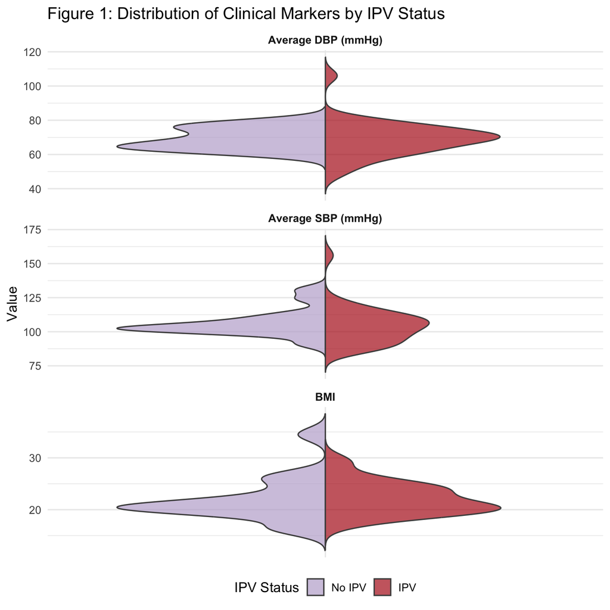

```r
pv_palette <- c(
  "No IPV" = "#beaed2",
  "IPV"    = "#b31b1b"
)


complete_data_sub <- complete_data |>
  dplyr::select(exp_any_violence, bmi, avg_sbp, avg_dbp) |>
  filter(!is.na(exp_any_violence)) |>
  mutate(
    exp_any_violence = case_when(
      exp_any_violence %in% c("Yes", "yes", "1", 1, "IPV") ~ "IPV",
      exp_any_violence %in% c("No", "no", "0", 0, "No IPV") ~ "No IPV",
      TRUE ~ as.character(exp_any_violence)
    ),
    exp_any_violence = factor(exp_any_violence, levels = c("No IPV", "IPV"))
  ) |>
  pivot_longer(
    cols = c(bmi, avg_sbp, avg_dbp),
    names_to = "marker",
    values_to = "value"
  ) |>
  mutate(
    marker = recode(marker,
      bmi = "BMI",
      avg_sbp = "Average SBP (mmHg)",
      avg_dbp = "Average DBP (mmHg)"
    )
  )

ggplot(complete_data_sub, aes(x = marker, y = value, fill = exp_any_violence)) +
  geom_split_violin(alpha = 0.7, color = "grey30", trim = FALSE) +
  facet_wrap(~ marker, scales = "free", ncol = 1) +
  scale_fill_manual(values = pv_palette) +
  labs(
    x = NULL,
    y = "Value",
    fill = "IPV Status",
    title = "Figure 1: Distribution of Clinical Markers by IPV Status"
  ) +
  theme_minimal(base_size = 13) +
  theme(
    legend.position = "bottom",
    strip.text = element_text(face = "bold"),
    axis.text.x = element_blank(),
    axis.ticks.x = element_blank()
  )
```

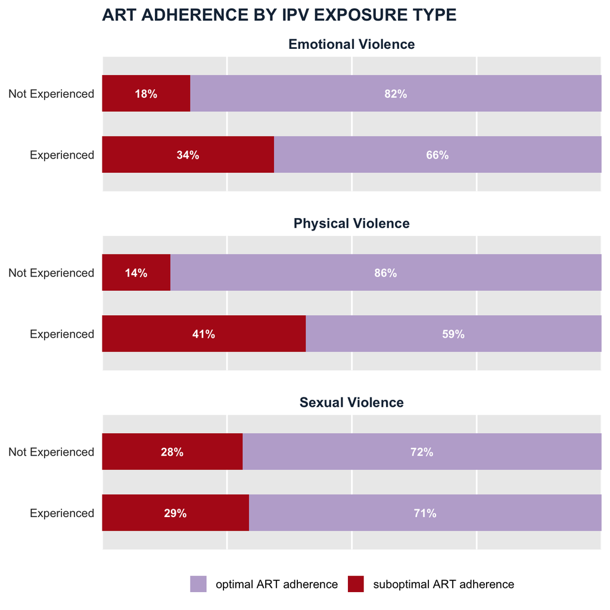

```r
viz_data <- complete_data |>
  dplyr::select(art_adherence_binary, exp_sex_violence, exp_emo_violence, exp_phy_violence) |>
  drop_na() |>
  pivot_longer(
    cols = c(exp_sex_violence, exp_emo_violence, exp_phy_violence),
    names_to = "violence_type",
    values_to = "exposure_status"
  ) |>
  mutate(
    violence_type = recode(violence_type,
      exp_sex_violence = "Sexual Violence",
      exp_emo_violence = "Emotional Violence",
      exp_phy_violence = "Physical Violence"
    ),
    exposure_label = case_when(
      exposure_status == "yes" ~ "Experienced",
      exposure_status == "no"  ~ "Not Experienced",
      TRUE ~ as.character(exposure_status)
    )
  )

summary_data <- viz_data |>
  group_by(violence_type, exposure_label, art_adherence_binary) |>
  summarise(n = n(), .groups = "drop") |>
  group_by(violence_type, exposure_label) |>
  mutate(prop = n / sum(n)) |>
  ungroup()

ggplot(summary_data, aes(x = prop, y = exposure_label, fill = art_adherence_binary)) +
  geom_col(width = 0.6) +
  geom_text(
    aes(label = percent(prop, accuracy = 1)),
    position = position_stack(vjust = 0.5),
    color = "white",
    fontface = "bold",
    size = 3.8
  ) +
  facet_wrap(~violence_type, ncol = 1, scales = "free_y") +
  scale_fill_manual(
    values = c("optimal ART adherence" = "#beaed2", "suboptimal ART adherence" = "#b31b1b"),
    name = NULL
  ) +
  scale_x_continuous(labels = scales::percent, expand = c(0, 0)) +
  labs(
    title = "ART ADHERENCE BY IPV EXPOSURE TYPE",
    x = NULL,
    y = NULL
  ) +
  theme_minimal(base_size = 16) +
  theme(
    plot.title = element_text(face = "bold", size = 16, color = "#1a2e44", margin = margin(b = 6)),
    panel.background = element_rect(fill = "#ececec", color = NA),
    plot.background = element_rect(fill = "white", color = NA),
    panel.grid.major.x = element_line(color = "white"),
    panel.grid.major.y = element_blank(),
    panel.grid.minor = element_blank(),
    axis.text.y = element_text(size = 11, color = "grey20"),
    axis.text.x = element_blank(),
    legend.position = "bottom",
    legend.text = element_text(size = 11),
    strip.text = element_text(face = "bold", size = 13, color = "#1a2e44"),
    strip.background = element_rect(fill = "white", color = NA),
    panel.spacing = unit(1.2, "lines")
  )
```

## 3. Does HIV stigma mediate the relationship between IPV and ART adherence?

```r
mediate_data <- complete_data |>
  mutate(art_adherence_number = if_else(art_adherence_binary == "optimal ART adherence",1,0)) |>
  mutate(ipv_count_number = if_else(ipv_count == "Experienced IPV",1,0)) |>
  dplyr::select(enacted_stigma, ipv_count_number, age, art_adherence_number) |>
  drop_na()
#mediation analysis

#create model from exposure to mediator
mod_1 = glm(enacted_stigma~ipv_count_number + age, family = binomial, data=mediate_data)
# mediation analysis mediator to outcome
mod_2 = glm(art_adherence_number~enacted_stigma + ipv_count_number + age, family = binomial, data = mediate_data)

#estimate direct and indirect effects
# proportion mediated
mediation_results = mediate(mod_1, mod_2, sims = 50, treat = "ipv_count_number", mediator = "enacted_stigma")

summary(mediation_results)
```

```
##
## Causal Mediation Analysis
##
## Quasi-Bayesian Confidence Intervals
##
##                           Estimate 95% CI Lower 95% CI Upper p-value
## ACME (control)           -0.035253    -0.142458     0.025717    0.24
## ACME (treated)           -0.051551    -0.162472     0.026948    0.24
## ADE (control)            -0.170703    -0.445722     0.052006    0.16
## ADE (treated)            -0.187002    -0.484114     0.052531    0.16
## Total Effect             -0.222255    -0.504392     0.063716    0.16
## Prop. Mediated (control)  0.128286    -0.163531     0.992747    0.24
## Prop. Mediated (treated)  0.203317    -0.165717     1.003070    0.24
## ACME (average)           -0.043402    -0.148939     0.026272    0.24
## ADE (average)            -0.178853    -0.462994     0.052269    0.16
## Prop. Mediated (average)  0.165801    -0.164624     0.997908    0.24
##
## Sample Size Used: 49
##
##
## Simulations: 50
```

## 4. Does depression mediate the relationship between IPV and ART adherence?

```r
mediate_data_deression <- complete_data |>
  mutate(art_adherence_number = if_else(art_adherence_binary == "optimal ART adherence",1,0)) |>
  mutate(ipv_count_number = if_else(ipv_count == "Experienced IPV",1,0)) |>
  dplyr::select(phq9_score, ipv_count_number, age, art_adherence_number) |>
  drop_na()
#mediation analysis
#create model from exposure to mediator
mod_1 = glm(phq9_score ~ ipv_count_number + age, family = gaussian , data=mediate_data_deression)
# mediation analysis mediator to outcome
mod_2 = glm(art_adherence_number ~ phq9_score + ipv_count_number + age, family = gaussian, data = mediate_data_deression)

#estimate direct and indirect effcts
# proportion mediated
mediation_results = mediate(mod_1, mod_2, sims = 50, treat = "ipv_count_number", mediator = "phq9_score")

summary(mediation_results)
```

```
##
## Causal Mediation Analysis
##
## Quasi-Bayesian Confidence Intervals
##
##                  Estimate 95% CI Lower 95% CI Upper p-value
## ACME           -0.0724685   -0.1887281   -0.0034749    0.04 *
## ADE            -0.2133194   -0.5127849    0.1110601    0.12
## Total Effect   -0.2857879   -0.5494522   -0.0352855  <2e-16 ***
## Prop. Mediated  0.2416828    0.0171925    5.0267299    0.04 *
## ---
## Signif. codes:  0 '***' 0.001 '**' 0.01 '*' 0.05 '.' 0.1 ' ' 1
##
## Sample Size Used: 49
##
##
## Simulations: 50
```

## 5. Does social support buffer (modify) the relationship between IPV and Depression?

*Moderation Interpretation:*

Tables : Among participants with high social support (n = 19), there were no statistically significant differences in depression, depression severity, ART adherence, or tolerance toward violence between participants who experienced IPV and those who did not (all p > 0.05). Depression was reported by 7.7% of participants who experienced IPV compared with 0% of those without IPV experience (p > 0.9). Similarly, among participants with moderate or low social support (n = 30), depression did not significantly differ between participants who experienced IPV and those who did not (14% vs. 22%, p = 0.6). No statistically significant differences were observed in depression severity, depression score, ART adherence, or depression/suicide within the moderate/low social support stratum (all p > 0.05). These descriptive stratified analyses did not provide evidence of a statistically significant difference in the association between IPV and depression across levels of social support.

### Moderation Analysis

```r
mediate_data_social <- complete_data |>
  mutate(art_adherence_number = if_else(art_adherence_binary == "optimal ART adherence",1,0)) |>
  mutate(ipv_count_number = if_else(ipv_count == "Experienced IPV",1,0)) |>
  dplyr::select(mspss_mean, phq9_score, enacted_stigma, ipv_count_number, age, art_adherence_number) |>
  drop_na()

# Modification analysis mediator to outcome

mod_1_social = glm(phq9_score~ipv_count_number*mspss_mean + age, family = gaussian, data=mediate_data_social)

tbl_regression(
  mod_1_social,
  label = list(
      ipv_count_number = "IPV",
      mspss_mean = "Social support score",
      age = "Age",
      `ipv_count_number * mspss_mean` = "IPV:Social support score"))
```

| **Characteristic** | **Beta** | **95% CI** | **p-value** |
| --- | --- | --- | --- |
| IPV | -4.0 | -14, 5.6 | 0.4 |
| Social support score | -2.8 | -4.5, -1.0 | 0.004 |
| Age | 0.01 | -0.50, 0.52 | >0.9 |
| IPV * Social support score | 1.2 | -0.79, 3.2 | 0.2 |

Abbreviation: CI = Confidence Interval

### Table 3A. High Social Support

```r
high_support_data <- complete_data |>
  mutate() |>
  filter(mspss_support_level %in% c("High"))

tbl_high_support <- high_support_data |>
 dplyr::select(phq9_binary, mspss_mean, ipv_count, art_adherence_binary, phq9_severity  ,attitudes_tolerate_binary, depression_suicide) |>

  tbl_summary(
    by = c("ipv_count"),
    label = list(
      phq9_binary = "Depression (PHQ9 binary)",
      depression_suicide = "Expirence Depression/Suicide",
      phq9_severity = "Depression Serverity",
      mspss_mean = "Average MSPSS (Social Support)",
      art_adherence_binary = "ART adherence binary",
      attitudes_tolerate_binary = "Tolerance towrds Violence"
    ),
  ) |>
  bold_labels() |>
  add_p() |>
 modify_caption("**Table 3A. Depression and ART Adherence by IPV Status (High Social Support)**")

tbl_high_support
```

**Table 3A. Depression and ART Adherence by IPV Status (High Social Support)**

| **Characteristic** | **Experienced IPV** N = 13<sup>1</sup> | **No IPV** N = 6<sup>1</sup> | **p-value**<sup>2</sup> |
| --- | --- | --- | --- |
| Depression (PHQ9 binary) | 1 (7.7%) | 0 (0%) | >0.9 |
| Average MSPSS (Social Support) | 6.00 (5.36, 6.36) | 5.73 (5.36, 5.82) | 0.6 |
| ART adherence binary |  |  | 0.6 |
| optimal ART adherence | 8 (62%) | 5 (83%) |  |
| suboptimal ART adherence | 5 (38%) | 1 (17%) |  |
| Depression Serverity |  |  | 0.7 |
| Mild | 2 (15%) | 0 (0%) |  |
| Minimal | 10 (77%) | 6 (100%) |  |
| Moderate | 1 (7.7%) | 0 (0%) |  |
| Tolerance towrds Violence |  |  | >0.9 |
| women should not tolerate | 11 (85%) | 5 (83%) |  |
| women should tolerate | 2 (15%) | 1 (17%) |  |
| Expirence Depression/Suicide | 2 (15%) | 0 (0%) | >0.9 |

<sup>1</sup> n (%); Median (Q1, Q3)  
<sup>2</sup> Fisher’s exact test; Wilcoxon rank sum test

### Table 3B. Moderate/Low Social Support

```r
low_moderate_support_data <- complete_data |>
  mutate() |>
  filter(mspss_support_level %in% c("Low", "Moderate"))

tbl_low_support <- low_moderate_support_data |>
  dplyr::select(phq9_binary, mspss_mean, mspss_support_level, ipv_count, art_adherence_binary, phq9_severity, phq9_score,attitudes_tolerate_binary, depression_suicide) |>

  tbl_summary(
    by = c("ipv_count"),
    label = list(
      phq9_binary = "Depression (PHQ9 binary)",
      depression_suicide = "Experience Depression/Suicide",
      phq9_severity = "Depression Serverity",
      phq9_score = "Depression Score",
      mspss_mean = "Average MSPSS (Social Support Score)",
      mspss_support_level = "MSPSS Support Category",
      art_adherence_binary = "ART Adherence Binary",
      attitudes_tolerate_binary = "Tolerance towards Violence"
    ),
    type = list(mspss_mean = "continuous"),
    statistic = list(mspss_mean ~ "{mean} ({sd})")
  ) |>
  bold_labels() |>
  add_p() |>
 modify_caption("**Table 3B. Depression and ART Adherence by IPV Status (Moderate/Low Social Support )**")

tbl_low_support
```

**Table 3B. Depression and ART Adherence by IPV Status (Moderate/Low Social Support )**

| **Characteristic** | **Experienced IPV** N = 21<sup>1</sup> | **No IPV** N = 9<sup>1</sup> | **p-value**<sup>2</sup> |
| --- | --- | --- | --- |
| Depression (PHQ9 binary) | 3 (14%) | 2 (22%) | 0.6 |
| Average MSPSS (Social Support Score) | 3.90 (0.81) | 4.17 (0.68) | 0.4 |
| MSPSS Support Category |  |  | >0.9 |
| Low | 1 (4.8%) | 0 (0%) |  |
| Moderate | 20 (95%) | 9 (100%) |  |
| ART Adherence Binary |  |  | 0.4 |
| optimal ART adherence | 14 (67%) | 8 (89%) |  |
| suboptimal ART adherence | 7 (33%) | 1 (11%) |  |
| Depression Serverity |  |  | 0.5 |
| Mild | 12 (57%) | 3 (33%) |  |
| Minimal | 6 (29%) | 4 (44%) |  |
| Moderate | 2 (9.5%) | 2 (22%) |  |
| Moderately severe | 1 (4.8%) | 0 (0%) |  |
| Depression Score | 6.0 (4.0, 8.0) | 5.0 (0.0, 7.0) | 0.4 |
| Tolerance towards Violence |  |  | 0.14 |
| women should not tolerate | 15 (71%) | 9 (100%) |  |
| women should tolerate | 6 (29%) | 0 (0%) |  |
| Experience Depression/Suicide | 7 (33%) | 4 (44%) | 0.7 |

<sup>1</sup> n (%); Mean (SD); Median (Q1, Q3)  
<sup>2</sup> Fisher’s exact test; Wilcoxon rank sum test

### Table 3C. Descriptive statistics of MSPSS cohort

```r
table_mspss <- complete_data |>
  dplyr::select(mspss_total, mspss_mean, mspss_support_level,
         mspss_family, mspss_friends, mspss_significant_other,
         ipv_count, art_adherence_binary) |>
  tbl_summary(
    by = c("art_adherence_binary"),
    label = list(
      mspss_total = "Total Social Support Score (MSPSS)",
      mspss_mean = "Mean Social Support Score",
      mspss_support_level = "Social Support Level",
      mspss_family = "Family Support",
      mspss_friends = "Friends Support",
      mspss_significant_other = "Significant Other Support",
      ipv_count = "IPV Expirence"

    ),
    type = list(
      mspss_total = "continuous",
      mspss_mean = "continuous",
      mspss_family = "continuous",
      mspss_friends = "continuous",
      mspss_significant_other = "continuous"
    ),
    statistic = list(
      all_continuous() ~ "{mean} ({sd})"
    )
  ) |>
  bold_labels() |>
  add_p() |>
  modify_caption("**Table 3C: Descriptive statistics of MSPSS cohort**")


table_mspss
```

**Table 3C: Descriptive statistics of MSPSS cohort**

| **Characteristic** | **optimal ART adherence** N = 217<sup>1</sup> | **suboptimal ART adherence** N = 82<sup>1</sup> | **p-value**<sup>2</sup> |
| --- | --- | --- | --- |
| Total Social Support Score (MSPSS) | 57 (11) | 53 (11) | 0.013 |
| Mean Social Support Score | 5.16 (1.03) | 4.83 (1.01) | 0.013 |
| Social Support Level |  |  | 0.4 |
| High | 113 (52%) | 37 (45%) |  |
| Low | 3 (1.4%) | 2 (2.4%) |  |
| Moderate | 101 (47%) | 43 (52%) |  |
| Family Support | 5.69 (1.25) | 5.34 (1.35) | 0.032 |
| Friends Support | 4.72 (1.25) | 4.37 (1.17) | 0.035 |
| Significant Other Support | 5.04 (1.21) | 4.75 (1.08) | 0.080 |
| IPV Expirence |  |  | 0.2 |
| Experienced IPV | 22 (63%) | 12 (86%) |  |
| No IPV | 13 (37%) | 2 (14%) |  |
| Unknown | 182 | 68 |  |

<sup>1</sup> Mean (SD); n (%)  
<sup>2</sup> Wilcoxon rank sum test; Fisher’s exact test

## 6. Amongst the full cohort (not limited to those reporting being in a relationship), what is the relationship between depression and HIV viral suppression?

Among the full cohort, the prevalence of binary depression did not significantly differ between participants with suppressed and unsuppressed HIV viral load (7.7% vs. 7.5%, p > 0.9). Similarly, depression/suicide did not significantly differ by HIV viral suppression status (13% vs. 10%, p = 0.6), and there was no statistically significant difference in depression severity (p = 0.5) or depression scores (median: 2.0 [Q1, Q3: 0.0, 6.0] vs. 2.0 [Q1, Q3: 0.0, 4.5], p = 0.4). ART adherence also did not significantly differ by HIV viral suppression status (p = 0.7).

### Table 4

```r
tbl_depression_vl <- complete_data |>
  dplyr::select(phq9_binary, hiv_vl_binary, depression_suicide, phq9_severity, phq9_score, art_adherence_binary ) |>
  tbl_summary(
    by = c("hiv_vl_binary"),
    label = list(
      phq9_binary = "Depression (PHQ9 binary)",
      phq9_severity = "Depression Serverity",
      phq9_score = "Depression Score",
      art_adherence_binary = "ART Adherence"
    )
  ) |>
  bold_labels() |>
  add_p() |>
  modify_caption("**Table 4: Depression and HIV viral suppression, full cohort**") |>
  add_overall()

tbl_depression_vl
```

**Table 4: Depression and HIV viral suppression, full cohort**

| **Characteristic** | **Overall** N = 288<sup>1</sup> | **suppressed** N = 248<sup>1</sup> | **unsuppressed** N = 40<sup>1</sup> | **p-value**<sup>2</sup> |
| --- | --- | --- | --- | --- |
| Depression (PHQ9 binary) | 22 (7.6%) | 19 (7.7%) | 3 (7.5%) | >0.9 |
| depression_suicide | 37 (13%) | 33 (13%) | 4 (10%) | 0.6 |
| Depression Serverity |  |  |  | 0.5 |
| Mild | 76 (26%) | 69 (28%) | 7 (18%) |  |
| Minimal | 190 (66%) | 160 (65%) | 30 (75%) |  |
| Moderate | 21 (7.3%) | 18 (7.3%) | 3 (7.5%) |  |
| Moderately severe | 1 (0.3%) | 1 (0.4%) | 0 (0%) |  |
| Depression Score | 2.0 (0.0, 6.0) | 2.0 (0.0, 6.0) | 2.0 (0.0, 4.5) | 0.4 |
| ART Adherence |  |  |  | 0.7 |
| optimal ART adherence | 209 (73%) | 181 (73%) | 28 (70%) |  |
| suboptimal ART adherence | 79 (27%) | 67 (27%) | 12 (30%) |  |

<sup>1</sup> n (%); Median (Q1, Q3)  
<sup>2</sup> Fisher’s exact test; Pearson’s Chi-squared test; Wilcoxon rank sum test

Division of Biostatistics

Department of Population Health Sciences

Ayisha Beauge, Celine Hernandez